# best-advertising-markets

Jianxuan Li

2026-01-13

# Introduction

This project combines descriptive statistics and distribution analysis to answer a practical marketing question: where should an e-learning platform advertise its programming courses? Using a dataset of survey responses from people learning to code, we explore where learners are located and how they invest in learning.

Our goal is to identify the two best markets for advertising by evaluating both the number of potential customers and their estimated monthly spending on learning resources.

# Understanding the Data

The dataset used in this project is extracted from freeCodeCamp’s 2017 New Coder Survey. It is publicly available in freeCodeCamp’s GitHub repository(https://github.com/freeCodeCamp/2017-new-coder-survey).

A brief overview of the dataset is shown below.

```r
library(readr)
library(dplyr)
library(ggplot2)
library(stringr)
# load the data
survey <- read_csv("../data/clean-data/2017-fCC-New-Coders-Survey-Data.csv")
# look for number of rows and columns
dim(survey)
```

```
## [1] 18175   136
```

```r
# first five rows
head(survey, 5)
```

```
## # A tibble: 5 × 136
##     Age AttendedBootcamp BootcampFinish BootcampLoanYesNo BootcampName
##   <dbl>            <dbl>          <dbl>             <dbl> <chr>
## 1    27                0             NA                NA <NA>
## 2    34                0             NA                NA <NA>
## 3    21                0             NA                NA <NA>
## 4    26                0             NA                NA <NA>
## 5    20                0             NA                NA <NA>
## # ℹ 131 more variables: BootcampRecommend <dbl>, ChildrenNumber <dbl>,
## #   CityPopulation <chr>, CodeEventConferences <dbl>,
## #   CodeEventDjangoGirls <dbl>, CodeEventFCC <dbl>, CodeEventGameJam <dbl>,
## #   CodeEventGirlDev <dbl>, CodeEventHackathons <dbl>, CodeEventMeetup <dbl>,
## #   CodeEventNodeSchool <dbl>, CodeEventNone <dbl>, CodeEventOther <chr>,
## #   CodeEventRailsBridge <dbl>, CodeEventRailsGirls <dbl>,
## #   CodeEventStartUpWknd <dbl>, CodeEventWkdBootcamps <dbl>, …
```

# Checking for Sample Representativity

For the purpose of our analysis, we focus on a population of new coders who are interested in the subjects offered by our e-learning platform. In this part, we aim to answer three key questions:

- Where are these new coders located?
- What are the locations with the greatest number of new coders?
- How much money new coders are willing to spend on learning?

```r
# the JobRoleInterest column describes for every participant the role(s) they'd be interested in working
# filter out the JobRoleInterest column and create the frequency distribution table
# drop NA values
interest_dist <- survey %>%
  select(JobRoleInterest) %>%
  filter(!is.na(JobRoleInterest)) %>%
  count(JobRoleInterest, sort = TRUE) %>%
  mutate(percent = n / sum(n) * 100)
interest_dist
```

```
## # A tibble: 3,211 × 3
##    JobRoleInterest                                         n percent
##    <chr>                                               <int>   <dbl>
##  1 Full-Stack Web Developer                              823  11.8
##  2 Front-End Web Developer                               450   6.44
##  3 Data Scientist                                        152   2.17
##  4 Back-End Web Developer                                142   2.03
##  5 Mobile Developer                                      117   1.67
##  6 Game Developer                                        114   1.63
##  7 Information Security                                   92   1.32
##  8 Full-Stack Web Developer,   Front-End Web Developer    64   0.915
##  9 Front-End Web Developer, Full-Stack Web Developer      56   0.801
## 10 Product Manager                                        55   0.787
## # ℹ 3,201 more rows
```

From the data above, we can summarize that, many people are interested in full-stack web developer, front-end web developer, and data scientist.

It’s also interesting to note that many respondents are interested in more than one subject. It’d be useful to get a better picture of how many people are interested in a single subject and how many have mixed interests. To determine whether respondents focus on a single subject or have more than one interest, we compare these two tables.

```r
# create the frequency table
# drop NA values
interest_freq_table <- survey %>%
  select(JobRoleInterest) %>%
  filter(!is.na(JobRoleInterest)) %>%
  mutate(n_interests = str_count(JobRoleInterest, ",") + 1
  ) %>%
  count(n_interests) %>%
  mutate(percent = n / sum(n) * 100)
# show the frequency table
interest_freq_table
```

```
## # A tibble: 13 × 3
##    n_interests     n percent
##          <dbl> <int>   <dbl>
##  1           1  2213 31.7
##  2           2   761 10.9
##  3           3  1111 15.9
##  4           4  1064 15.2
##  5           5   842 12.0
##  6           6   470  6.72
##  7           7   270  3.86
##  8           8   123  1.76
##  9           9    69  0.987
## 10          10    33  0.472
## 11          11    13  0.186
## 12          12    21  0.300
## 13          13     2  0.0286
```

According to the frequent table above, ~31.7% new coders are interested in one job, while the remaining ~68.3% listed 2 or more interests(many list 3–5 roles). The majority of new coders do not determine their career path, which suggests that they are willing to explore several jobs simultaneously. Although most new coders have multiple interests, the sample is still representative as overlap is not a bad thing for our advertisement. Since web and mobile development appear frequently among these interests, the situation would be suitable for our market analysis.

The focus of our courses is on **web** and **mobile** development.So next, we will figure out how many new coders are interested in at least one of the two subjects.

```r
# detect the presence of Web Developer or Mobile Developer
web_or_mobile <- str_detect(string = survey$JobRoleInterest,
                            pattern = "Web Developer|Mobile Developer"
)
# create the frequency table
# convert web_or_mobile to df
# drop NA values
wm_freq_table <- tibble(web_or_mobile = web_or_mobile) %>%
  summarise(n_wm = sum(web_or_mobile, na.rm = TRUE),
            total = sum(!is.na(web_or_mobile)),
            pct_wm = n_wm / total * 100
  )
# check the result
wm_freq_table
```

```
## # A tibble: 1 × 3
##    n_wm total pct_wm
##   <int> <int>  <dbl>
## 1  6030  6992   86.2
```

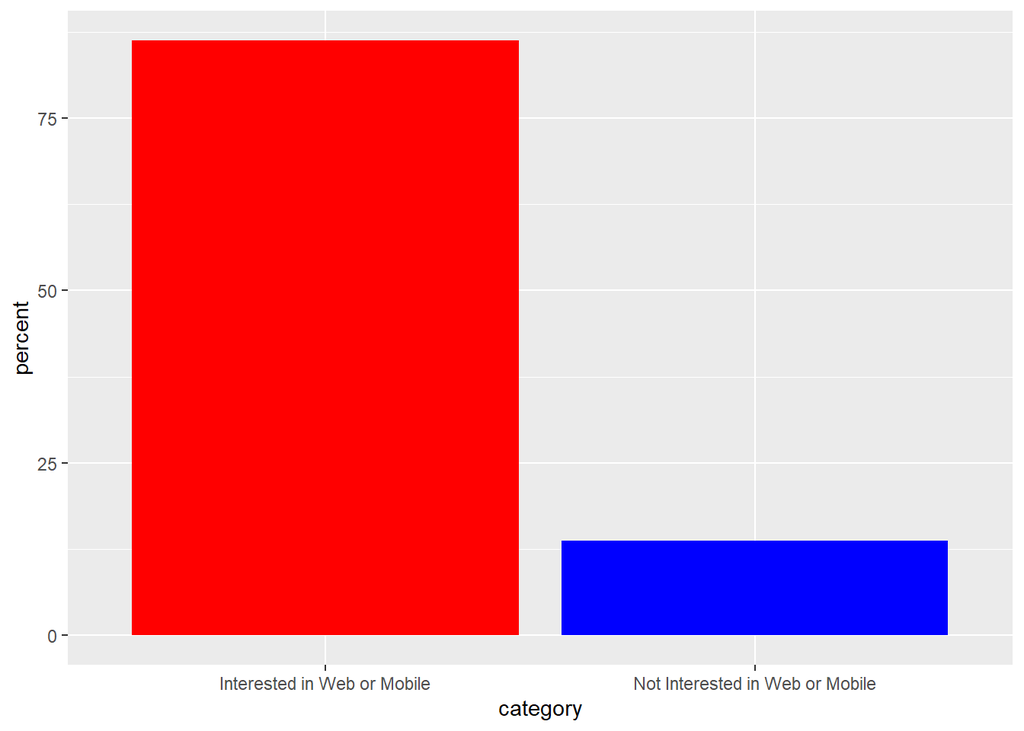

```r
# generate the graph
wm_plot_data <- tibble(category = c("Interested in Web or Mobile",
                             "Not Interested in Web or Mobile"),
                       percent = c(wm_freq_table$pct_wm,
                                   100 - wm_freq_table$pct_wm
                       )
)
ggplot(wm_plot_data, aes(x = category, y = percent)) +
  geom_col(fill = c("red", "blue"))
```

There are ~86.2% new coders are interested in web development, or mobile development, or both. This suggests that a very large majority of the new coders are interested in at least one of the two areas, which supports the idea that this dataset is appropriate for our analysis goal.

# New Coders - Locations and Densities

Since the sample contains the appropriate target audience, we can analyze where new coders are currently located and compare market sizes by country. Using the **CountryLive** variable to represent each country as a separate market, we focus on the number of potential customers, since converting a small percentage of a large market is more effective than fully converting a very small one.

```r
# drop rows that include na values in the JobRoleInterest column
survey_clean <- survey %>%
  tidyr::drop_na(JobRoleInterest)
# generate a frequency table for the CountryLive variable with both absolute and relative frequencies
countrylive_freq_table <- survey_clean %>%
  count(CountryLive, name = "absolute_frequency") %>%
  mutate(relative_frequency = `absolute_frequency` /
                              sum(`absolute_frequency`) * 100) %>%
  arrange(desc(relative_frequency))
# display the frequency table
countrylive_freq_table
```

```
## # A tibble: 138 × 3
##    CountryLive              absolute_frequency relative_frequency
##    <chr>                                 <int>              <dbl>
##  1 United States of America               3125              44.7
##  2 India                                   528               7.55
##  3 United Kingdom                          315               4.51
##  4 Canada                                  260               3.72
##  5 <NA>                                    154               2.20
##  6 Poland                                  131               1.87
##  7 Brazil                                  129               1.84
##  8 Germany                                 125               1.79
##  9 Australia                               112               1.60
## 10 Russia                                  102               1.46
## # ℹ 128 more rows
```

The table above shows that participants are not evenly distributed across countries. The US has the largest number of participants, accounting for ~44.7% of the sample. India (~7.56%) and the United Kingdom (~4.5%) rank second and third, but their shares are much smaller than that of the US Based on the data, the US and India would be the best two markets to advertise in.

Although the data suggests the top two markets, other variables, such as *MoneyForLearning*, are also important.

# Spending Money for Learning

In this part, we will figure out how much money new coders are willing to spend on learning. The *MoneyForLearning* column describes in American dollars the amount of money spent by participants from the moment they started coding until the moment they completed the survey.

Also, it is necessary to narrow down our analysis to these four countries: the US, India, the United Kingdom, and Canada, as the courses are written in English.

```r
# replace all the values of 0 with 1 to avoid dividing by 0
survey_clean <- survey_clean %>%
  mutate(MonthsProgramming = replace(
         MonthsProgramming, MonthsProgramming == 0, 1)
  )
# create a new column that describes the amount of money a student has spent per month
# divide the MoneyForLearning column to the MonthsProgramming column
survey_clean <- survey_clean %>%
  mutate(money_per_month = MoneyForLearning/MonthsProgramming)
# count the number of null values in the new column
null_values <- sum(is.na(survey_clean$money_per_month))
null_values
```

```
## [1] 675
```

```r
# keep only the rows without a null value
survey_clean <- survey_clean %>%
  tidyr::drop_na(money_per_month)
# remove rows that have null values in the CountryLive column
survey_clean <- survey_clean %>%
  tidyr::drop_na(CountryLive)
# group the CountryLive column and find out how much money a student spends on average each month in the US, India, the United Kingdom and Canada
country_avg <- survey_clean %>%
  group_by(CountryLive) %>%
  filter(CountryLive == 'United States of America' | CountryLive == 'India' |
         CountryLive == 'United Kingdom'|CountryLive == 'Canada') %>%
  summarise(country_mean = mean(money_per_month)
  )%>%
  arrange(desc(country_mean))
# show the result
country_avg
```

```
## # A tibble: 4 × 2
##   CountryLive              country_mean
##   <chr>                           <dbl>
## 1 United States of America        228.
## 2 India                           135.
## 3 Canada                          114.
## 4 United Kingdom                   45.5
```

# Dealing with Extreme Outliers

The results for the United Kingdom and Canada are surprisingly low compared to the values for India, which may be caused by outliers. Therefore, we need to examine the data more closely.

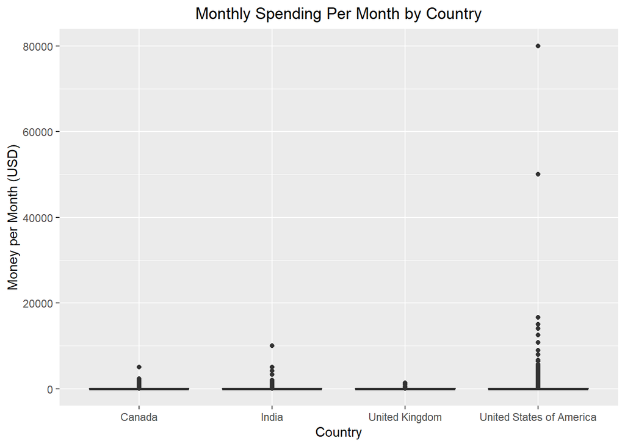

```r
# filter out the four countries
four_countries <- c("United States of America", "India", "United Kingdom", "Canada")
four_survey_clean <- survey_clean %>%
  filter(CountryLive %in% four_countries)
# generate four box plots on the same figure
ggplot(four_survey_clean, aes(x = CountryLive, y = money_per_month)) +
  geom_boxplot() +
  labs(title = "Monthly Spending Per Month by Country",
       x = "Country",
       y = "Money per Month (USD)") +
  theme(plot.title = element_text(hjust = 0.5))
```

We can see two extreme points for the United States, where two persons spend more than $50,000 per month. These values are likely outliers that affect our analysis. Therefore, we remove all values greater than $20,000. For the other three countries, extreme outliers are harder to identify.

```r
# remove the outliers
survey_clean <- survey_clean %>%
  filter(money_per_month < 20000)
# recompute the mean
country_avg_re <- survey_clean %>%
  group_by(CountryLive) %>%
  filter(CountryLive == 'United States of America' | CountryLive == 'India' |
         CountryLive == 'United Kingdom'|CountryLive == 'Canada') %>%
  summarise(country_mean = mean(money_per_month)
  )%>%
  arrange(desc(country_mean))
country_avg_re
```

```
## # A tibble: 4 × 2
##   CountryLive              country_mean
##   <chr>                           <dbl>
## 1 United States of America        184.
## 2 India                           135.
## 3 Canada                          114.
## 4 United Kingdom                   45.5
```

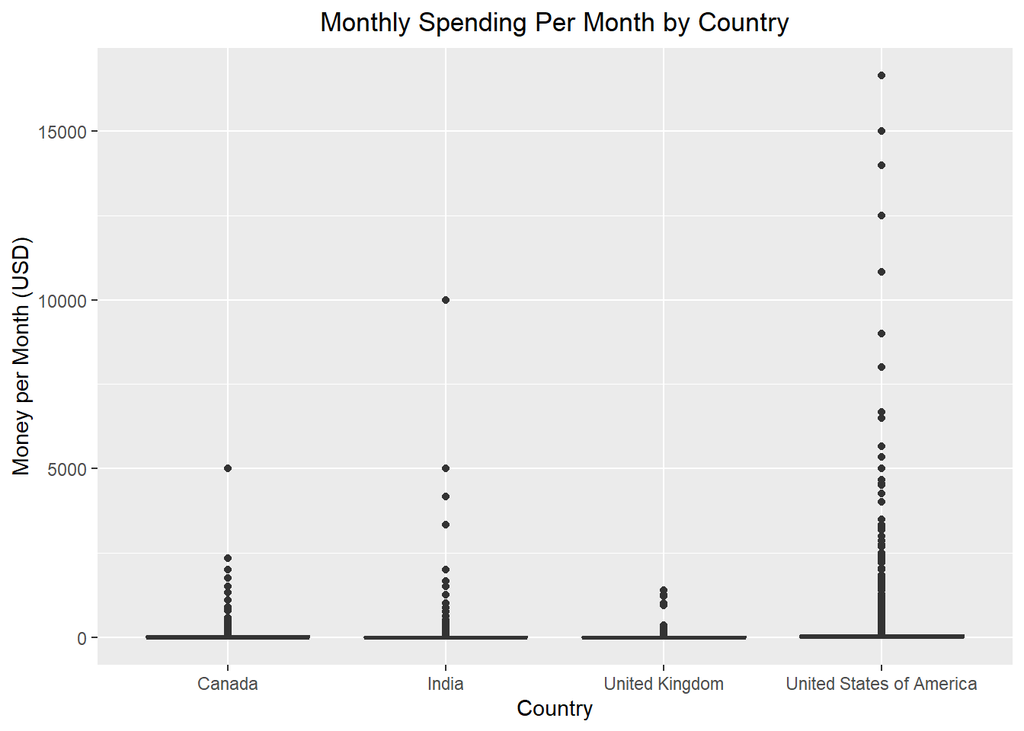

```r
#regenerate the box plots
four_countries <- c("United States of America", "India", "United Kingdom", "Canada")
four_survey_clean <- survey_clean %>%
  filter(CountryLive %in% four_countries)
# generate four box plots on the same figure
ggplot(four_survey_clean, aes(x = CountryLive, y = money_per_month)) +
  geom_boxplot() +
  labs(title = "Monthly Spending Per Month by Country",
       x = "Country",
       y = "Money per Month (USD)") +
  theme(plot.title = element_text(hjust = 0.5))
```

The data is better than before, but there are still some outliers. From the box plot, we can see several outliers above $10,000–$17,000 for the US, some outliers around $5,000–$10,000 for India, and a few outliers around $5,000 for Canada.

However, we are not sure whether these values should be removed. Therefore, we need to examine these outliers more closely to determine whether they are valid.

```r
# find out the outliers for the US
us_outliers <- four_survey_clean %>%
  filter(CountryLive == 'United States of America' &
           money_per_month > 6000)
# check the outliers
us_outliers
```

```
## # A tibble: 11 × 137
##      Age AttendedBootcamp BootcampFinish BootcampLoanYesNo BootcampName
##    <dbl>            <dbl>          <dbl>             <dbl> <chr>
##  1    26                1              0                 0 The Coding Boot Camp…
##  2    32                1              0                 0 The Iron Yard
##  3    34                1              1                 0 We Can Code IT
##  4    31                0             NA                NA <NA>
##  5    46                1              1                 1 Sabio.la
##  6    32                0             NA                NA <NA>
##  7    26                1              0                 1 Codeup
##  8    33                1              0                 1 Grand Circus
##  9    29                0             NA                NA <NA>
## 10    27                0             NA                NA <NA>
## 11    50                0             NA                NA <NA>
## # ℹ 132 more variables: BootcampRecommend <dbl>, ChildrenNumber <dbl>,
## #   CityPopulation <chr>, CodeEventConferences <dbl>,
## #   CodeEventDjangoGirls <dbl>, CodeEventFCC <dbl>, CodeEventGameJam <dbl>,
## #   CodeEventGirlDev <dbl>, CodeEventHackathons <dbl>, CodeEventMeetup <dbl>,
## #   CodeEventNodeSchool <dbl>, CodeEventNone <dbl>, CodeEventOther <chr>,
## #   CodeEventRailsBridge <dbl>, CodeEventRailsGirls <dbl>,
## #   CodeEventStartUpWknd <dbl>, CodeEventWkdBootcamps <dbl>, …
```

Many U.S. outliers appear to be bootcamp students, so these values may be valid. We will remove those rows where participants reported that they spend $6,000 each month, but they have never attended a bootcamp.

Moreover, we spot that there are 8 students had been programming for no more than three months when they completed the survey. They most likely paid a large sum of money for a bootcamp that was going to last for several months, so the amount of money spent per month is unrealistic and should be significantly lower. As a consequence, we’ll also remove these 8 outliers.

```r
# remove outliers that did not attend the boot camp
four_survey_clean <- four_survey_clean %>%
  filter(!(CountryLive == "United States of America" &
           AttendedBootcamp == 0 &
           money_per_month >= 6000)
  )
# remove outliers that had been programming for no more than three months
four_survey_clean <- four_survey_clean %>%
  filter(!(CountryLive == "United States of America" &
           money_per_month >= 6000 &
           MonthsProgramming <= 3)
  )
```

```r
# find out the outliers for India
india_outliers <- four_survey_clean %>%
  filter(CountryLive == 'India' &
           money_per_month > 2500)
# check the outliers
india_outliers
```

```
## # A tibble: 6 × 137
##     Age AttendedBootcamp BootcampFinish BootcampLoanYesNo BootcampName
##   <dbl>            <dbl>          <dbl>             <dbl> <chr>
## 1    24                0             NA                NA <NA>
## 2    20                0             NA                NA <NA>
## 3    28                0             NA                NA <NA>
## 4    22                0             NA                NA <NA>
## 5    19                0             NA                NA <NA>
## 6    27                0             NA                NA <NA>
## # ℹ 132 more variables: BootcampRecommend <dbl>, ChildrenNumber <dbl>,
## #   CityPopulation <chr>, CodeEventConferences <dbl>,
## #   CodeEventDjangoGirls <dbl>, CodeEventFCC <dbl>, CodeEventGameJam <dbl>,
## #   CodeEventGirlDev <dbl>, CodeEventHackathons <dbl>, CodeEventMeetup <dbl>,
## #   CodeEventNodeSchool <dbl>, CodeEventNone <dbl>, CodeEventOther <chr>,
## #   CodeEventRailsBridge <dbl>, CodeEventRailsGirls <dbl>,
## #   CodeEventStartUpWknd <dbl>, CodeEventWkdBootcamps <dbl>, …
```

It looks like none of the people attended the boot camp. So it’s safer to remove those outliers.

```r
# remove India outliers
four_survey_clean <- four_survey_clean %>%
  filter(!(CountryLive == "India" &
           AttendedBootcamp == 0 &
           money_per_month >= 2500))
```

```r
# find out the outliers for Canada
canada_outliers <- four_survey_clean %>%
  filter(CountryLive == 'Canada' &
           money_per_month > 2500)
# check the outliers
canada_outliers
```

```
## # A tibble: 1 × 137
##     Age AttendedBootcamp BootcampFinish BootcampLoanYesNo BootcampName
##   <dbl>            <dbl>          <dbl>             <dbl> <chr>
## 1    24                1              0                 0 Bloc.io
## # ℹ 132 more variables: BootcampRecommend <dbl>, ChildrenNumber <dbl>,
## #   CityPopulation <chr>, CodeEventConferences <dbl>,
## #   CodeEventDjangoGirls <dbl>, CodeEventFCC <dbl>, CodeEventGameJam <dbl>,
## #   CodeEventGirlDev <dbl>, CodeEventHackathons <dbl>, CodeEventMeetup <dbl>,
## #   CodeEventNodeSchool <dbl>, CodeEventNone <dbl>, CodeEventOther <chr>,
## #   CodeEventRailsBridge <dbl>, CodeEventRailsGirls <dbl>,
## #   CodeEventStartUpWknd <dbl>, CodeEventWkdBootcamps <dbl>, …
```

There is only one participant who attended a boot camp but did not finish it. However, this person paid about $5,000 at enrollment and did not spend any money afterward. Therefore, we treat this case as an outlier and remove it from the analysis.

```r
# remove Canada outliers
four_survey_clean <- four_survey_clean %>%
  filter(!(CountryLive == "Canada" &
           money_per_month >= 2500))
```

Next, recompute the means.

```r
# recompute the means
recomputed_mean <- four_survey_clean %>%
  group_by(CountryLive) %>%
  summarise(country_mean = mean(money_per_month)) %>%
  arrange(desc(country_mean))
# show the result
recomputed_mean
```

```
## # A tibble: 4 × 2
##   CountryLive              country_mean
##   <chr>                           <dbl>
## 1 United States of America        143.
## 2 Canada                           93.1
## 3 India                            65.8
## 4 United Kingdom                   45.5
```

Graph the box plot again.

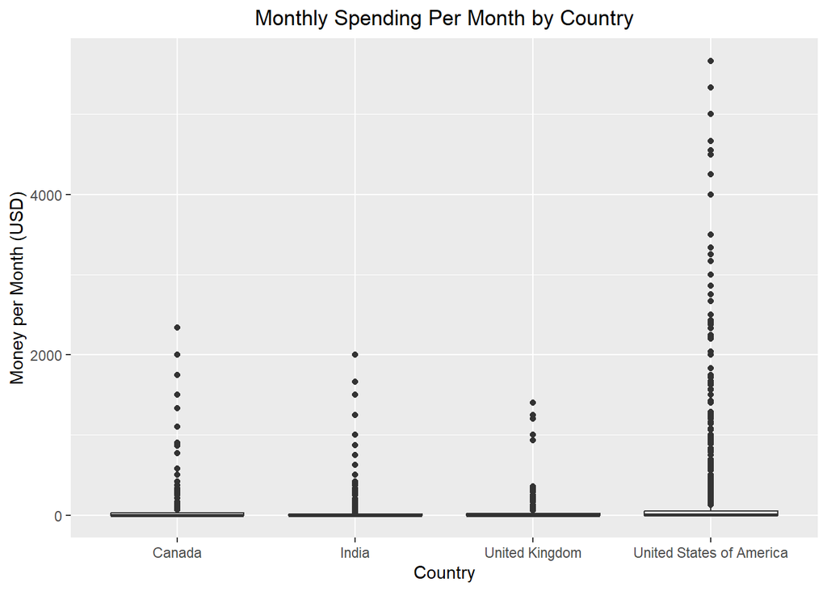

```r
#regenerate the box plots
ggplot(four_survey_clean, aes(x = CountryLive, y = money_per_month)) +
  geom_boxplot() +
  labs(title = "Monthly Spending Per Month by Country",
       x = "Country",
       y = "Money per Month (USD)") +
  theme(plot.title = element_text(hjust = 0.5))
```

# Choosing the Two Best Markets

To analysis the final result, we put all the results below here:

```r
# show the frequency table for the four countries in the CountryLive column
head(countrylive_freq_table, 4)
```

```
## # A tibble: 4 × 3
##   CountryLive              absolute_frequency relative_frequency
##   <chr>                                 <int>              <dbl>
## 1 United States of America               3125              44.7
## 2 India                                   528               7.55
## 3 United Kingdom                          315               4.51
## 4 Canada                                  260               3.72
```

Refer to the frequency table, the US stands out, which takes up ~45% of the new coders. India ranks second and has a much higher frequency than United Kingdom and Canada.

```r
# show the mean of the four countries
recomputed_mean
```

```
## # A tibble: 4 × 2
##   CountryLive              country_mean
##   <chr>                           <dbl>
## 1 United States of America        143.
## 2 Canada                           93.1
## 3 India                            65.8
## 4 United Kingdom                   45.5
```

Based on the cleaned spending data, the two best markets are the United States and Canada because they have the highest average monthly spending. Our company sells subscriptions at a price of $59 per month. New coders in the United States spend ~$143 per month on average, while those in Canada spend ~$93 per month. In comparison, average spending is much lower in India (~$66) and the United Kingdom (~$46), making the United States and Canada stronger choices from a spending perspective.

Considering all the results so far, the United States is clearly a market where we should advertise. It has a large number of new coders, and they are willing to spend a relatively high amount on learning each month. When choosing a second country, Canada appears to be a better option than India. Although India has a larger market size, the average amount that learners are willing to spend is significantly lower than in Canada. From a profitability standpoint, Canada is therefore the more suitable choice.

Taking all these factors into account, the United States and Canada are the two most suitable countries for advertising. Given the strong advantage shown in the U.S. data, it makes sense to allocate a larger share of the advertising budget to the U.S. market. For example, the budget could be split unevenly, such as 70% for the U.S. and 30% for Canada, or 60% for the U.S. and 40% for Canada.

# Conclusion